Skip to content

Statistical modeling, for the people it serves

# Can family engagement close the achievement gap?

The one intervention that costs nothing may help the children who need it most. Here is what 25,391 students tell us.

**By Cynthia Mutua** / Data: National Center for Education Statistics, 2016 & 2019 / Built in R with tidymodels

25,391

students across two national survey waves

18%

4

statistical models, all pointing the same way

The problem

## A family's income still predicts a child's report card

Among the highest earners, 62.3% of children bring home mostly A's. Among the lowest earners, that figure is 36.5%. The 25.8 point gap between them is not a gap in ability. It is a gap in the resources a family can put behind a child, and those resources are not shared out evenly.

Most programs built to close it quietly widen it instead. Tutoring is claimed first by families who already have the time and the internet to find it. Advanced classes go to students whose parents know how to work the system. Even free summer programs run into transport, cost, and scheduling.

Family engagement looked different for one reason: it does not cost money. Showing up to a parent-teacher meeting, helping with homework, coming to a school event, none of it requires wealth. The real question was not whether engagement helps. It clearly does. The question was whether it helps *more* for the students furthest behind. Education researchers call this the compensatory hypothesis, and it is what this project set out to test.

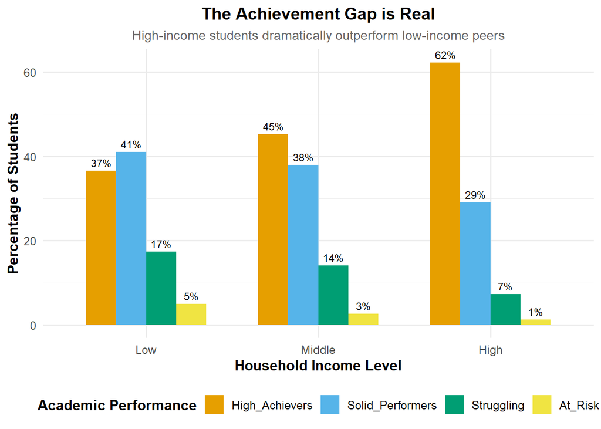

**Figure 1.** Academic performance by household income. The share of high achievers climbs steadily with income, while the at-risk and struggling groups shrink.

Does engagement help disadvantaged students more than advantaged ones?

The data and the method

## Building a measure that isn't just noise

25,391 K-12 students, drawn from a national survey and modeled so a single missed meeting never masquerades as a finding.

The data comes from the NCES Parent and Family Involvement in Education survey, combining its 2016 and 2019 waves. After cleaning, 25,391 students remained, each with grades, an at-risk flag, and days absent, alongside eight school activities, homework habits, cultural enrichment, income, parent education, and family structure.

A single missed event says nothing on its own, it might just be a scheduling clash that week. So rather than model each activity separately, I built three composite measures to capture the *breadth* of a family's involvement instead of any one data point: a count of eight school activities, a standardized homework-involvement score, and a weighted cultural-enrichment score.

Testing the compensatory idea meant testing an *interaction*, not just a main effect. Entered separately, income and engagement can only tell you engagement helps on average. An income-by-engagement term is what lets the data say whether it helps *unevenly*, which is the entire policy question.

The one line that answers the question

step_interact(~ income : school_engagement) # A negative, significant coefficient here means engagement # lowers risk more for low-income students: # the compensatory signature we set out to find.

R 4.3tidymodelsggplot2nnetMASS75/25 split10-fold cross-validation

Who engages, and why

### The gap in engagement is smaller than you'd think

Higher-income families do engage more, averaging 4.54 of the eight activities against 3.66 for lower-income families. But that 0.88 activity gap tracks structural barriers, inflexible work hours, transport, unwelcoming schools, far more than it tracks interest.

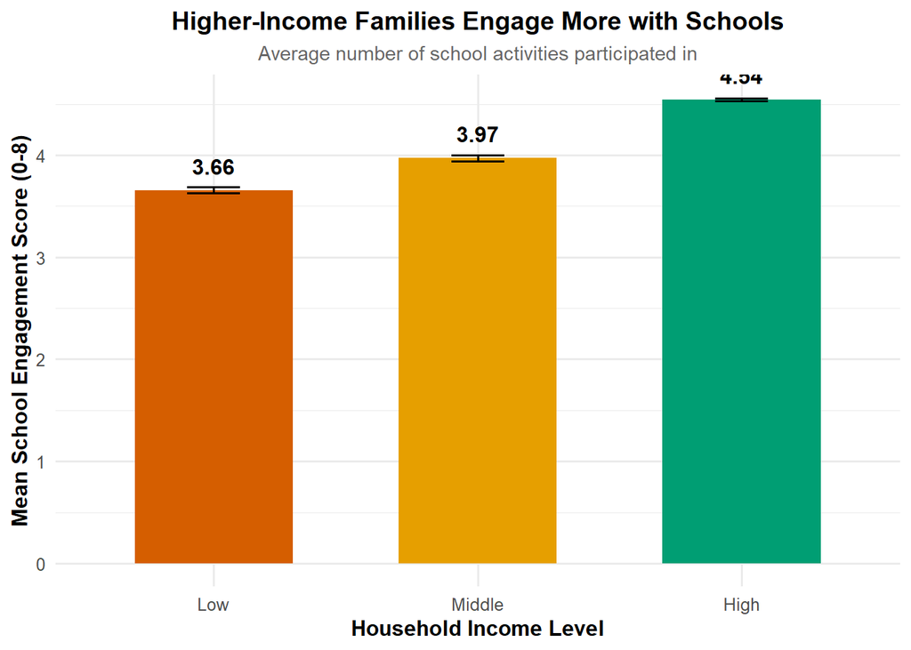

**Figure 2.** Average school activities attended, out of eight, by income.

The core finding

## The same activity does more for the students who have less.

−0.20

The income-by-engagement coefficient is negative and significant (p = 0.009). In plain terms, each added activity lowers a low-income student's at-risk odds by roughly 18%, against 10% for a higher-income student. An effect this size would appear by chance less than 1% of the time.

What the numbers show

## Engagement helps everyone, and helps them unequally

Move a student from low to high engagement and both groups improve. The students who start furthest behind gain the most, relative to where they began.

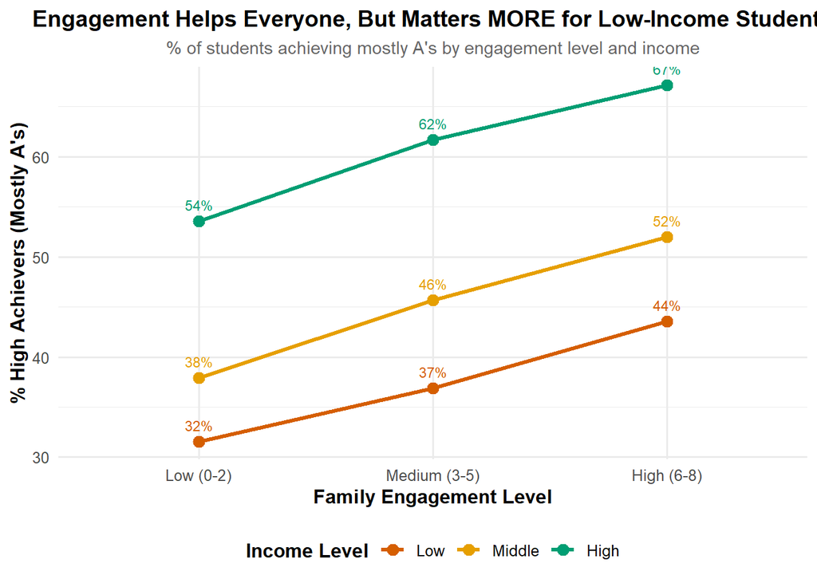

**Figure 3.** Share of high achievers by engagement level and income. Every line rises, but the lower-income lines climb most steeply relative to their starting point.

At low engagement, 32% of low-income students earn mostly A's. At high engagement, 44% do, a 37.5% relative jump. Higher-income students climb from 54% to 67% over the same range, a 24.1% relative gain. The wealthier group still gains more raw percentage points, but the lower-income group gains more relative to where it started. That is the compensatory effect, and it holds across every model that tests it.

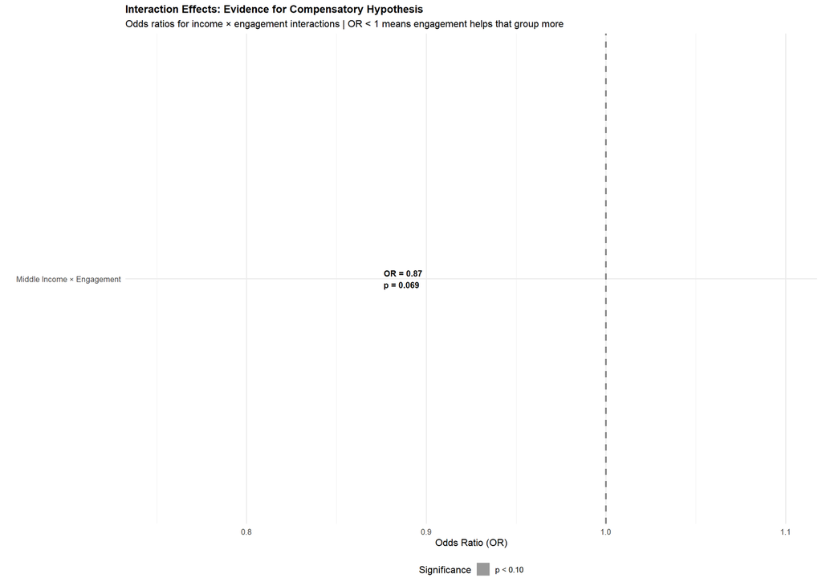

Not every form of engagement carries equal weight. Ranked by standardized effect on at-risk odds, homework involvement is the clear front-runner.

1. 01

#### Homework involvement

   Odds ratio 0.59, a 41% drop in at-risk odds per standard deviation. The single strongest predictor in the model.
2. 02

#### Cultural enrichment

   Library trips, reading, museums and shared activities carry a real, significant protective effect.
3. 03

#### Breadth of school engagement

   Odds ratio 0.90 per activity. Showing up across many activities matters more than any single event.

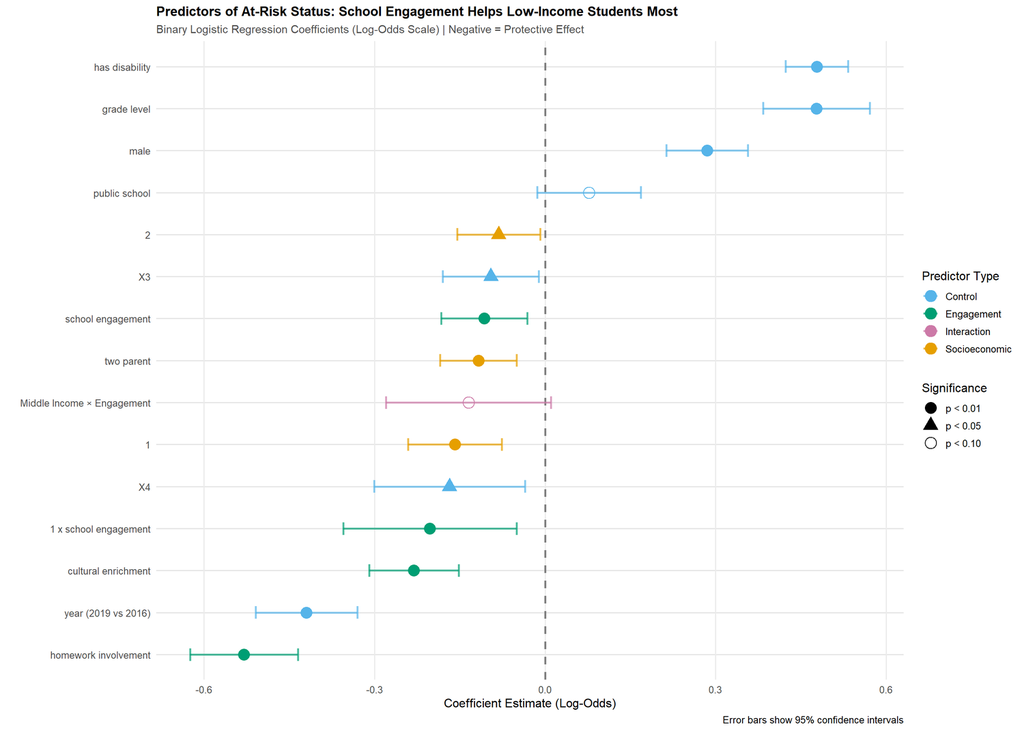

**Figure 5.** Standardized predictors of at-risk status. Note that having a disability is the strongest single risk factor here (odds ratio 1.61), and calls for its own targeted support rather than family engagement alone.

One question, tested four ways

## Why four models instead of one

Grades, risk, and absences are three different kinds of outcome. Each needs its own model, and running several lets them check each other.

[output not shown]

The robustness check

The multinomial model and the linear discriminant analysis rest on different statistical assumptions, yet land within half a point of each other, 62.9% against 62.6%. When two methods that disagree on the math still agree on the answer, the finding is unlikely to be an artifact of modeling choices.

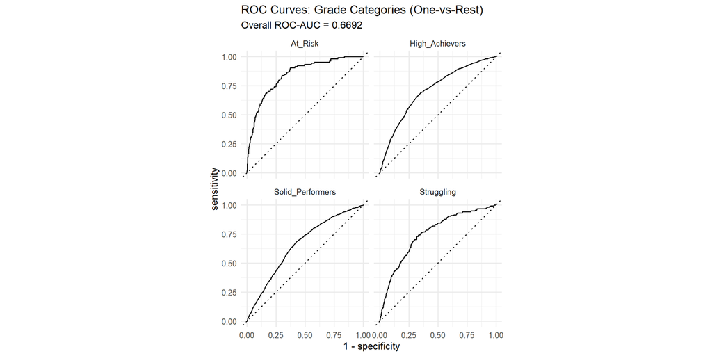

**Figure 6.** ROC curves for the primary model, one per grade band.

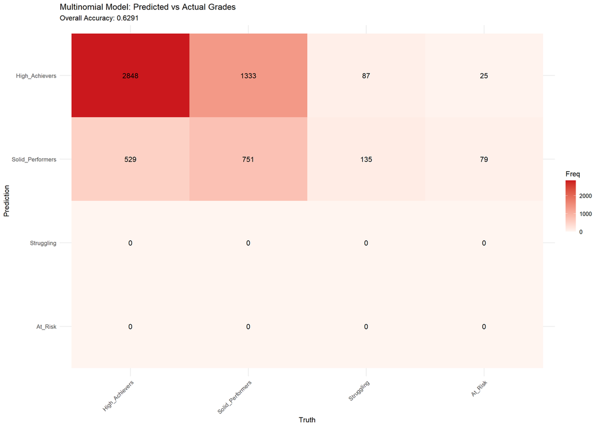

What to do about it

## Target the outreach, don't spread it thin

A program open to everyone in the same way is claimed first by the families with the most slack. The data argues for the opposite instinct: aim it at the students it helps most.

#### Where the evidence points

- Homework-help sessions at school, coaching parents to support effort, not supply answers
- Personal outreach to lower-income families, not a blanket invitation
- Removing the real barriers: transport, childcare, evening scheduling
- Parent-teacher conferences as the low-threshold entry point
- Dedicated support for students with disabilities, the strongest risk factor here

#### Where good intentions fall short

- Universal programs with no targeting, captured by the most flexible families
- Fundraising galas as a primary engagement channel
- One-size messaging that ignores families' actual barriers
- Weekday daytime events that quietly exclude working parents

~$200

per student, per year, for a homework-help program

~$12,000

cost of a single grade retention, per student

18%

lower at-risk probability, at a fraction of the cost

What it taught me

## The honest version of the story

I expected engagement to lift every student by about the same amount. Finding instead that it does more for the students starting furthest behind was the most hopeful result in the project: an equitable intervention does not have to be an expensive one.

The binary model's collapse was the sharper lesson. It is tempting to report the number that looks best. The version I stand behind shows the failure next to the fix, because a model that catches none of the students it exists to catch is not a success, whatever its accuracy score says.

The interaction is correlational, and I would want to strengthen the causal claim before a district spent real money on it: matching similar families who differ in engagement, natural experiments around policy changes, and tracking students over time to see whether the effect compounds across a school career.

Equity doesn't always need a bigger budget. Sometimes it needs **better aim**.

Four models, one steady signal: family engagement protects low-income students more than it protects anyone else. That is a lever most districts could pull tomorrow, and a reason for parents to believe their time at the kitchen table counts.

[View the code on GitHub](https://github.com/cece15/educational-equity-family-engagement) [Back to portfolio](https://cece15.github.io/C.-Mutua-Portfolio/)

Cynthia Mutua [LinkedIn](https://www.linkedin.com/in/cynthia-mutua/) [GitHub](https://github.com/cece15) cmutuaa@gmail.com